# Assignement 4

Manuela Giansante

2023-03-23

```r
# Necessary Packages
library(fpp2)
library(fpp3)
library(tsibble)
library(dbplyr)
library(fable)
library(tidyverse)
library(cowplot)
library(forecast)
library(fabletools)
library(kableExtra)
library(boot)
```

We present again the Paperback series in the tsibble format.

```r
# Load the data
paperback <- books[,1]

times <- seq(1, dim(books)[1], 1)    # vector for time
books_df <- data.frame(books[, 1:2])

books_tsibble <- books_df |>           # create tsibble object
  mutate(Time = times, .before=1) |>
  as_tsibble(index = Time)

books_tsibble
```

```
## # A tsibble: 30 x 3 [1]
##     Time Paperback Hardcover
##    <dbl>     <int>     <int>
##  1     1       199       139
##  2     2       172       128
##  3     3       111       172
##  4     4       209       139
##  5     5       161       191
##  6     6       119       168
##  7     7       195       170
##  8     8       195       145
##  9     9       131       184
## 10    10       183       135
## # ... with 20 more rows
```

```
## Plot variable not specified, automatically selected `.vars = Paperback`
```

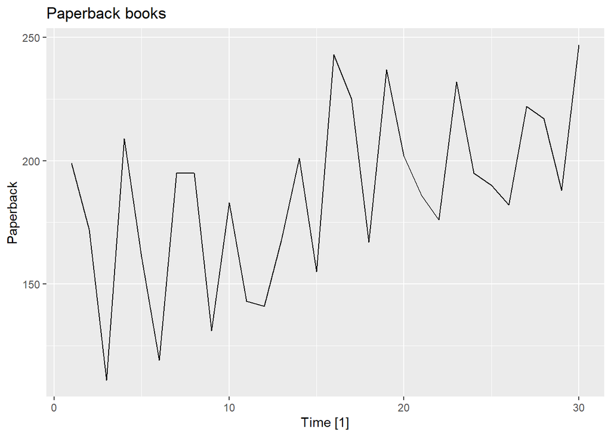

```r
# plot
autoplot(books_tsibble) + labs(title = "Paperback books")
```

The series displays not seasonality, the dips and the peaks appear to be fairly random. The model selected in the previous exercise is Holt’s model with additive error, damped additive trend and no seasonality. The model is described by:

$\begin{aligned}y_t&=l_{t-1}+\phi b_{t-1}+ \epsilon _t\\l_t&=l_{t-1}+\phi b_{t-1}+\alpha \epsilon_t\\b_t&=\phi b_{t-1}+ \beta\epsilon_t\end{aligned}$

Let’s fit the data with the ETS(A,Ad,N):

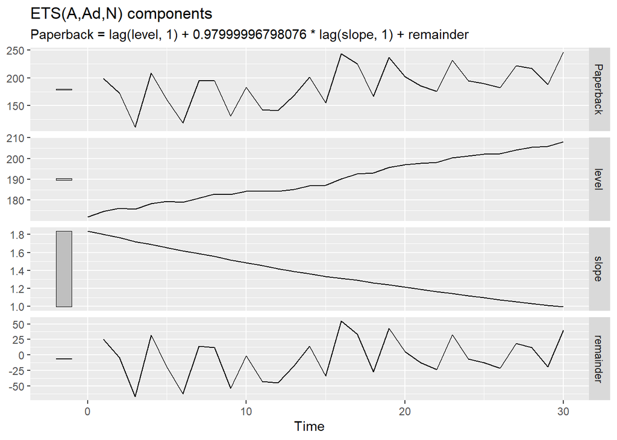

```r
# ETS model, "AAdN"
model_AAdN <- books_tsibble %>%
  model(`SES` = ETS(Paperback ~ error("A") + trend("Ad") + season("N")))

components(model_AAdN) %>%
  autoplot() +
  labs(title = "ETS(A,Ad,N) components")
```

```r
report(model_AAdN)
```

```
## Series: Paperback
## Model: ETS(A,Ad,N)
##   Smoothing parameters:
##     alpha = 0.03259223
##     beta  = 0.0001000242
##     phi   = 0.98
##
##   Initial states:
##      l[0]     b[0]
##  171.8317 1.835088
##
##   sigma^2:  1220.294
##
##      AIC     AICc      BIC
## 321.7717 325.4239 330.1789
```

The level of the model is almost a straight model which increase, because overall the series grows through time. The slope decreases because it signals how the the trend’s increment decreases over the time span.

The model’s smoothing parameters and initial states are printed out above. The damping parameter $\phi$ is very close to one, the model is not very not very far from a non damped modelling choice.

We compute the the 10 steps-ahead forecast:

```r
# Forecast
AAdN_fc <- model_AAdN %>%
  fabletools::forecast(h=10)
AAdN_fc
```

```
## # A fable: 10 x 4 [1]
## # Key:     .model [1]
##    .model  Time    Paperback .mean
##    <chr>  <dbl>       <dist> <dbl>
##  1 SES       31 N(209, 1220)  209.
##  2 SES       32 N(210, 1222)  210.
##  3 SES       33 N(211, 1223)  211.
##  4 SES       34 N(212, 1224)  212.
##  5 SES       35 N(213, 1226)  213.
##  6 SES       36 N(214, 1227)  214.
##  7 SES       37 N(215, 1228)  215.
##  8 SES       38 N(215, 1230)  215.
##  9 SES       39 N(216, 1231)  216.
## 10 SES       40 N(217, 1232)  217.
```

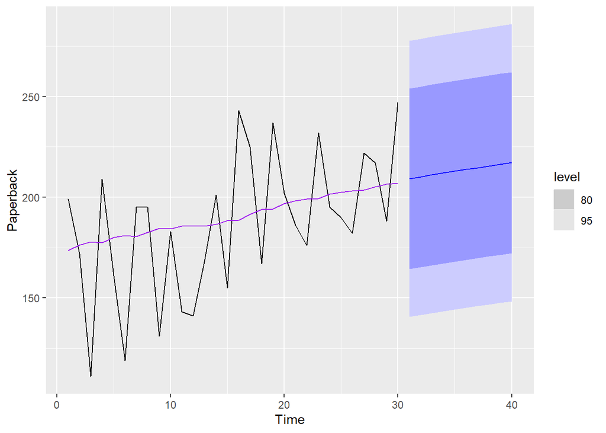

```r
# Plot data and forecast
AAdN_fc %>%
  autoplot(books_tsibble) +
  geom_line(aes(y = .fitted), col="purple",
            data = augment(model_AAdN))
```

The forecast function, generate a normally distributed forecast, in the Paperback columns on the left you have the mean of the CI, the value the point forecast takes at each step. On the right we have the variances which appear quite homogeneous.

The confidence interval of the forecast expresses how accurate the prediction is, it therefore accounts for all the movement in the data which could have not been utilized in the point forecast.

We run the some test on the innovation residuals:

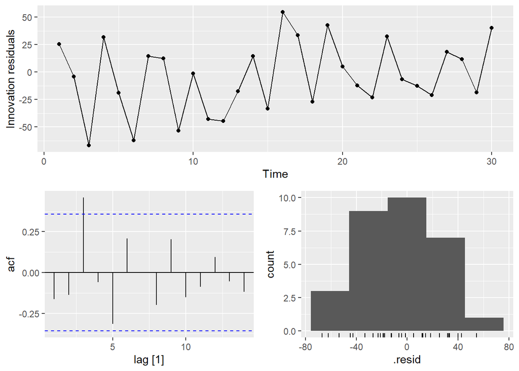

```r
# Diagnostics
model_AAdN %>% gg_tsresiduals()
```

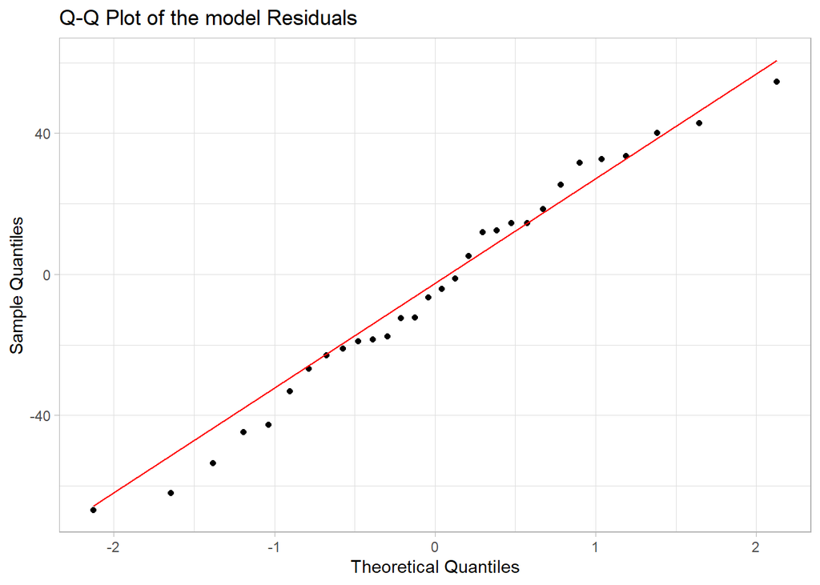

```r
# QQplot of residuals
fit_table<- augment(model_AAdN)
ggplot(fit_table, aes(sample = .resid)) +
  stat_qq() +
  stat_qq_line(col="red")+
  labs(title="Q-Q Plot of the model Residuals", x="Theoretical Quantiles", y= "Sample Quantiles")+ theme_light()
```

```r
# Shapiro-Wilk test
fit_table$.resid %>% shapiro.test()
```

```
##
##  Shapiro-Wilk normality test
##
## data:  .
## W = 0.97847, p-value = 0.7835
```

The Q-Q plot points in the same direction as the histogram, the residuals might not be normal. We run a statistical test.

With the Shapiro - Wilk we are testing the null-hypothesis that the sample comes from a normally distributed population. The p-value is larger than 0.5, therefore we fail to reject the h0. The residuals can be considered to normally distributed.

### In this exercise we replace the normal simulation by bootstrap.

In our context, bootstrap is a synonym for re-sampling. The idea is to draw at random the new error from the sample of estimated errors with replacement.

```r
set.seed(1234) # replicability
h.step <- 10 # 10-step ahead
R <- 100
# bootstrap
sim <- model_AAdN %>% generate(h = h.step, times = 10, bootstrap = TRUE) # with replacement
sim # we keep times to 10 for graphic reasons
```

```
## # A tsibble: 100 x 4 [1]
## # Key:       .model, .rep [10]
##    .model  Time .rep   .sim
##    <chr>  <dbl> <chr> <dbl>
##  1 SES       31 1      225.
##  2 SES       32 1      269.
##  3 SES       33 1      197.
##  4 SES       34 1      195.
##  5 SES       35 1      199.
##  6 SES       36 1      174.
##  7 SES       37 1      185.
##  8 SES       38 1      165.
##  9 SES       39 1      199.
## 10 SES       40 1      156.
## # ... with 90 more rows
```

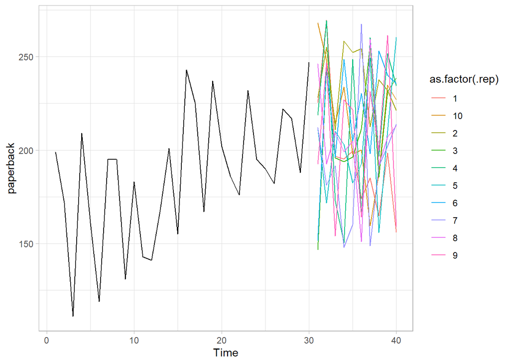

```r
# plot
books_tsibble %>%
  ggplot(aes(x = Time)) +
  geom_line(aes(y = paperback)) +
  geom_line(aes(y = .sim, colour = as.factor(.rep)),data = sim) + theme_light()
```

```r
# forecast
fc <- model_AAdN %>% forecast(h = h.step, bootstrap = TRUE, times= R)
head(fc)
```

```
## # A fable: 6 x 4 [1]
## # Key:     .model [1]
##   .model  Time   Paperback .mean
##   <chr>  <dbl>      <dist> <dbl>
## 1 SES       31 sample[100]  212.
## 2 SES       32 sample[100]  212.
## 3 SES       33 sample[100]  217.
## 4 SES       34 sample[100]  212.
## 5 SES       35 sample[100]  210.
## 6 SES       36 sample[100]  219.
```

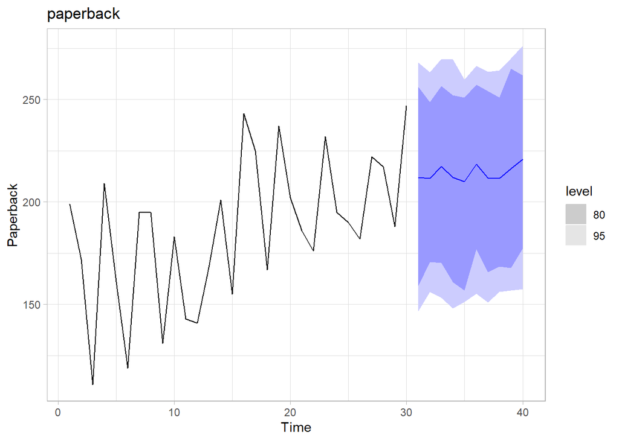

```r
autoplot(fc, books_tsibble) +labs(title="paperback")+theme_light()
```

The remainder of the model is re-sampled randomly 100 times with replacement, assuming the innovation errors will be similar to the ones from past observations.

The first step ahead looks like:

$\begin{aligned}y^*_{T+1}&= y_T+\epsilon ^*_{T+1}\\ y^*_{T+1}&=l_{T}+\phi b_{T}+\epsilon^*_{T+1}\end{aligned}$

The forecast is computed for h=10 steps for R=100 different times. The first time for readbility we only estimated 10 possible paths.

With the `forecast()` function we compute the point forecast for the next 10 days, but also the confidence intervals, which because of the missing normality assumption are not symmetric around the mean.

#### a. the prediction intervals at 95% for the 10-days ahead

```r
fc_mat<- unlist(fc$Paperback) %>% matrix(nr=10, ncol = R)
apply(fc_mat,1, quantile, probs=c(0.025, 0.975))
```

```
##           [,1]     [,2]     [,3]     [,4]     [,5]     [,6]     [,7]     [,8]
## 2.5%  152.3278 149.7768 154.3964 152.0645 151.4509 156.8722 154.2634 155.4806
## 97.5% 266.5917 265.3013 264.6553 267.9889 270.6614 268.7028 267.4326 272.6776
##           [,9]    [,10]
## 2.5%  147.3859 151.1567
## 97.5% 269.9910 260.2009
```

#### b. the distribution (histogram + summary numbers) of the total sales over the next 5-days

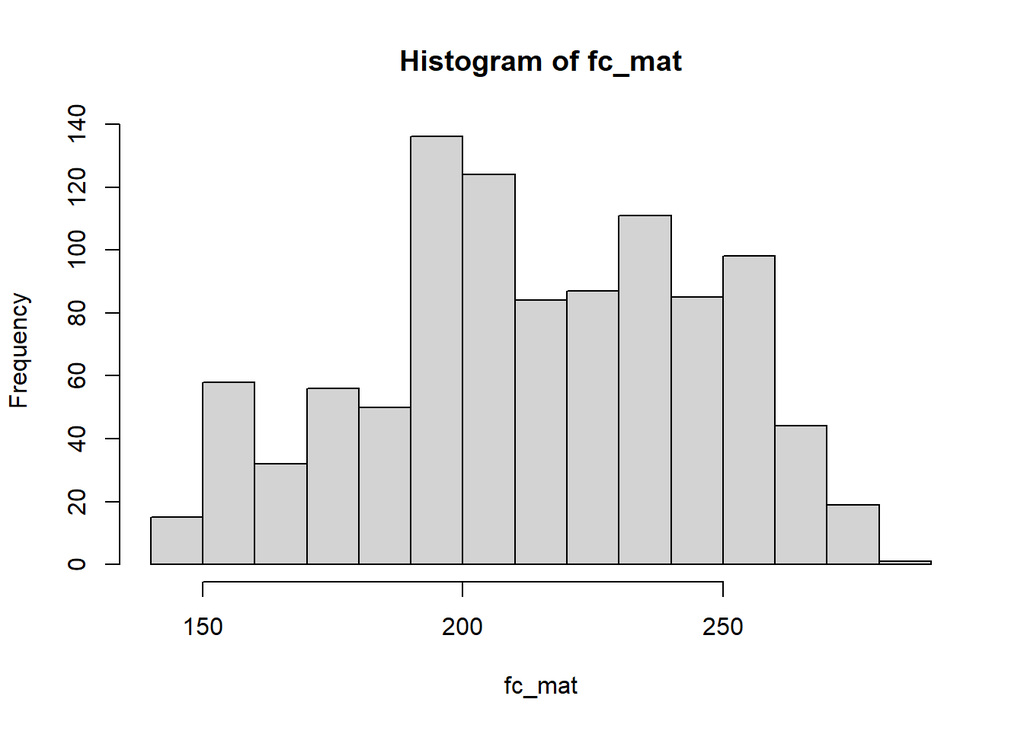

```r
hist(fc_mat, breaks=10)
```

```r
summary(fc[1:5,]$.mean)
```

```
##    Min. 1st Qu.  Median    Mean 3rd Qu.    Max.
##   210.0   211.5   211.9   212.5   212.0   217.3
```

The simulated distribution does not seem to follow normality, in fact its mean is not 0, and the tails of the curve are quite thick.

#### c. the probability that the sales will increase during the next 3-days.

```r
mean((fc_mat[1,]<fc_mat[2,])&(fc_mat[2,]<fc_mat[3,]))
```

```
## [1] 0.12
```

The probability that the sales will in crease in the next 3 days amounts to 12%.

### What does bootstrap mean taking into account the context of the exercise?

In this case bootstrapping entails the re-sampling of the estimated errors (so the remainder of the model) for R times, in order to generate a more reliable forecast.

When we simulated the 100 different possible forecasts we are re-suing the smoothing parameter estimated with the damped model.

Moreover, as already mentioned we are assuming that in the future sales of paperback books will not have unexpected extreme variations, so that the past observations are very close to the future ones.

### Why and when it can be applied?

It has to be applied in the case in which we cannot assume normality for the model residuals. If they appear to be close enough to a normal distribution, the mean and other summary statistics yielded from bootstrapping will be very similar to the ones obtained when assuming a distribution $N(0,\sigma^2)$. For example if the Shapiro test we run at the start turned out to reject the null hypothesis, because the p-value was just below 0.05.

In order to perform the re-sampling, we need to have a decent sizes sample of residuals to start with, otherwise when we plot the simulated data in an histogram we risk to have very structured patterns. Simulating innovation residuals from a a very small starting dataset will not improve the precision of our forecast.

Finally, it must be considered whether we can assume that the residuals “in the future” will be similar to the remainders of the model fitted on past data. This might not be the case if the index we are analysis has been subject to a big shock, a big drop or an out of norm peak, the re-sampling might select the outliers.